# Lab 9

Author

Giovanni Librizzi

# Revision

I accidentally had my labels for the legends in my plot in the wrong order, so i refactored to allow them to be in the right order. I also didn’t put the right y label on my regression equation, which I fixed.

### Setup

```r
library(tidyverse)
names_a <- read_csv(here::here("Week9", "Lab", "StateNames_A.csv"))
names_a <- names_a |>
  rename(Sex = Gender)
```

# 3. Summarizing & Visualizing the Number of Allisons

1.

```r
allison_data <- names_a |>
  filter(Name == "Allison") |>
  select(-Year) |>
  group_by(State, Sex) |>
  summarize(n = sum(Count)) |>
  pivot_wider(names_from = Sex,
              values_from = n,
              values_fill = 0) |>
  rename(Male = M, Female = F)
```

2.

```r
allison_f <- names_a |>
  filter(Name == "Allison",
         Sex == "F") |>
  select(-State) |>
  group_by(Year) |>
  summarize(n = sum(Count))
```

3.

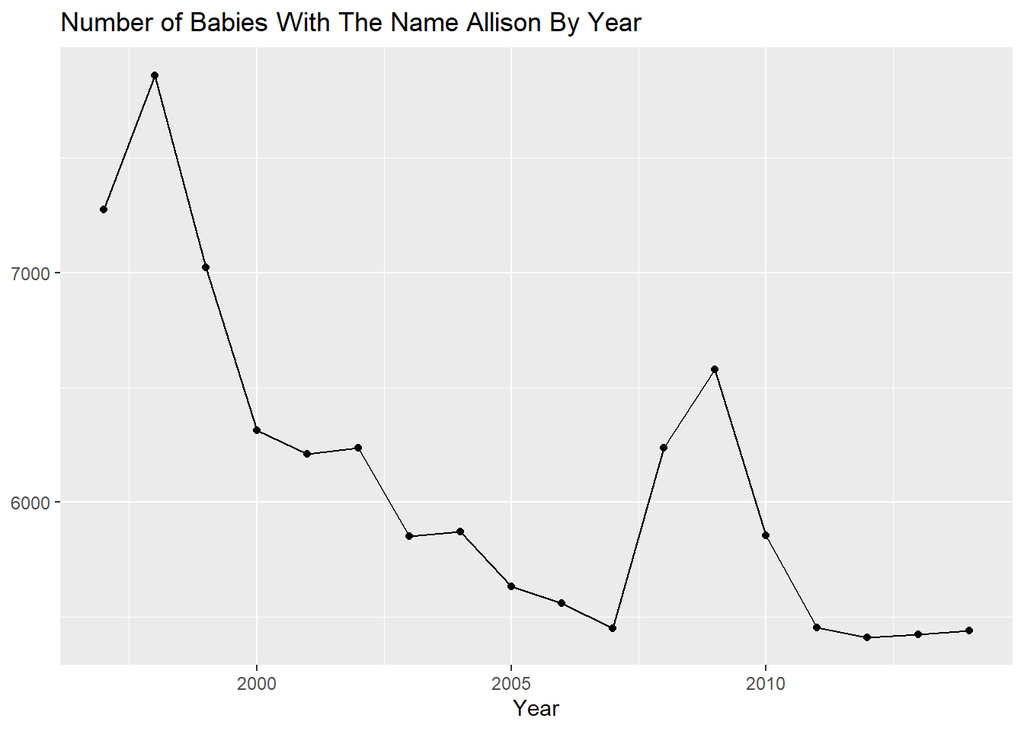

```r
allison_f |>
  ggplot(mapping = aes(x = Year, y = n)) +
  geom_line() +
  geom_point() +
  labs(y = NULL,
       title = "Number of Babies With The Name Allison By Year"
       )
```

# 4. Modeling the Number of Allisons

4. Fit a linear model with the year as the explanatory variable, and the number of Allisons as the response. Similar to #3, each year should have one observation–the total number of Allisons born that year.

```r
allison_lm <- lm(n ~ Year, data = allison_f)
```

5. Write out the estimated regression equation.

   babies_born_named_allison = 209689.8 - 101*Year
6. Plot the residuals of the model, that is, the actual values minus the predicted values. Comment on the residuals - do you see any patterns?

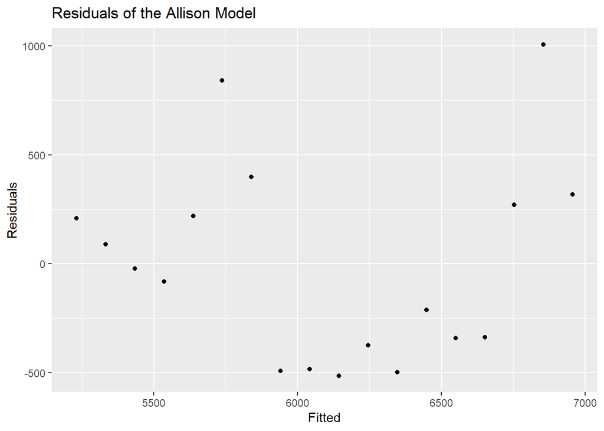

```r
allison_lm |>
  broom::augment() |>
  ggplot(mapping = aes(y = .resid, x = .fitted)) +
  geom_point() +
  labs(x = "Fitted",
       y = "Residuals",
       title = "Residuals of the Allison Model"
       )
```

7. From the spread of this model, we can see the name is very varied in popularity, but does seem to be more unpopular now

# 5. Spelling by State

8.

```r
alan_spelling <- names_a |>
  filter(Name %in% c("Allan", "Alan", "Allen")) |>
  group_by(Name, Year) |>
  summarize(n = sum(Count))
```

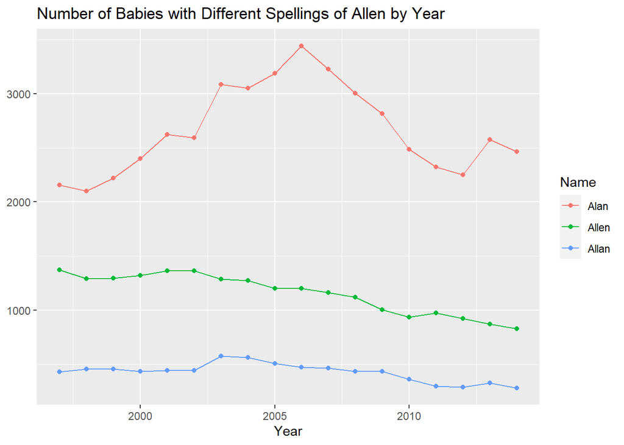

```r
alan_spelling |>
  ggplot(mapping = aes(x = Year,
                       y = n,
                       color = fct_reorder2(Name, Year, n)
                       )) +
  geom_line() +
  geom_point() +
  labs(
    y = NULL,
    title = "Number of Babies with Different Spellings of Allen by Year",
    color = "Name"
  )
```

9.

```r
allan_state <- names_a |>
  filter(Name %in% c("Allan", "Alan", "Allen"),
         Year == 2000,
         Sex == "M",
         State %in% c("CA", "PA")) |>
  select(-Sex, -Year) |>
  group_by(Name, State)

allan_state_wide <- allan_state |>
  pivot_wider(names_from = Name,
              values_from = Count,
              values_fill = 0)
```

```r
allan_state |>
  group_by(State) |>
  mutate(prop = round(Count / sum(Count), 4),
         prop = str_c(as.character(prop*100), "%")) |>
  select(-Count) |>
  pivot_wider(names_from = Name,
              values_from = prop,
              values_fill = "0%")
```

```
# A tibble: 2 × 4
# Groups:   State [2]
  State Alan   Allen  Allan
  <chr> <chr>  <chr>  <chr>
1 CA    65.35% 19.86% 14.79%
2 PA    42.86% 47.06% 10.08%
```